# **A Data-Driven Study of Skills in Demand Across the Job Market in the World**

**Collaborator:** Anantha Aksshaj Erigisetty  
**Course:** MSML 602  
**Date:** Fall 2025

# **Introduction**

The goal of this project is to study the current job market using real-time data that we collected from the internet. Today, many students and professionals want to understand which skills companies are asking for and what types of jobs are most common. Because the job market changes very quickly, using old datasets is not enough. We need updated information that reflects what employers are looking for right now.

This topic is important because data plays a major role in career development, hiring decisions, and skill-building. By analyzing job postings, we can discover which technical and non-technical skills are in high demand, how different regions vary in the jobs they offer, and what patterns exist in the job descriptions. This type of analysis is directly connected to data science because it uses data collection, cleaning, visualization, and simple machine learning to answer real-world questions.

In this project, I focus on the following main question:

“What skills are most in demand in the job market today, and how do these skills vary across locations and job categories?”

To answer this, I scraped job data using an online API, cleaned and organized the dataset, studied different job tags and skills, and built simple machine learning models to predict whether a job requires engineering-related skills.

# **Data Collection**

For this project, I needed a dataset that reflects the current job market, including job titles, companies, tags, and the skills employers are looking for. Instead of using an old or static dataset, I decided to collect live data directly from the internet. This makes the project more realistic because the job market changes every day.

I used the RemoteOK API, which is a public web API that provides real-time job postings from many different industries. The API returns useful information such as:

1. Job title
2. Company name
3. Date posted
4. Tags (skills and categories)
5. Job location
6. URL to the original posting

This data is ideal for analysis because it already contains structured fields, and it also includes tags that hint at the skills required for each job.

To collect the data, I sent an HTTP request to the API using Python. The response came back in JSON format, which I converted into a Pandas DataFrame. From there, I could view all the columns and start preparing the dataset for analysis.

Even though the API provides a lot of information, the raw data is not perfectly clean. Some postings have missing values, inconsistent tag formats, or repeated entries. Because of this, data cleaning was necessary before moving on to visualizations and modeling.

Before starting the analysis, I imported several Python libraries that I needed for this project. Each of these libraries plays an important role in data science and helps make the workflow easier:

NumPy and Pandas are the main libraries used for handling numerical data and working with tables (DataFrames). Pandas helps me load, clean, and organize the job data in a structured way.

Requests is used to connect to the RemoteOK API and download the job postings directly from the web.

Defaultdict from the collections module makes it easier to build dictionaries without worrying about missing keys, especially when counting skills or tags.

CountVectorizer from scikit-learn is a text-processing tool that converts job descriptions and tags into numerical features. This is needed later for machine learning models.

LogisticRegression from scikit-learn is one of the machine learning models I used to predict whether a job requires engineering skills.

These imports set up all the tools I needed for data collection, cleaning, visualization, and modeling throughout the project.

```python
import numpy as np
import pandas as pd


import requests


from collections import defaultdict


import matplotlib.pyplot as plt
import seaborn as sns


from sklearn.feature_extraction.text import CountVectorizer
from sklearn.linear_model import LogisticRegression
```

# **Data Processing**

During the data processing stage, I transformed the raw JSON data from the RemoteOK API into a clean and organized DataFrame. The API response includes metadata and fields that are not directly useful, so I first removed the extra metadata. For each job posting, I used a normalization function to extract the most important fields such as job ID, company, title, tags, location, and URL. I also converted the tags into a consistent string format because different jobs store tags differently. Finally, I combined all cleaned job records into a single Pandas DataFrame and removed rows with missing titles or companies. This gave me a structured and reliable dataset that I could use for visualization and machine learning.

```python
REMOTEOK_API_URL = "https://remoteok.com/api"

def fetch_remoteok_jobs():
    """
    Fetch all available jobs from the RemoteOK public API.

    Returns
    -------
    jobs : list of dict
        Raw job dictionaries as returned by the API (excluding the first metadata element).
    """

    headers = {
        "User-Agent": "Mozilla/5.0 (compatible; JobMarketProject/1.0; +https://example.com)"
    }

    response = requests.get(REMOTEOK_API_URL, headers=headers)
    response.raise_for_status()

    data = response.json()


    jobs = data[1:]
    return jobs
```

```python
def normalize_job_record(job):
    """
    Transform one raw job dictionary from RemoteOK into a cleaner, consistent format.

    Parameters
    ----------
    job : dict
        Raw job item from the RemoteOK API.

    Returns
    -------
    record : dict
        Normalized job record with selected fields.
    """

    tags = job.get("tags") or []
    if isinstance(tags, list):
        tags_str = ", ".join(tags)
    else:
        tags_str = str(tags)

    return {
        "job_id": job.get("id"),
        "date": job.get("date"),
        "company": job.get("company"),
        "title": job.get("position") or job.get("title"),
        "tags": tags_str,          # skills / technologies as comma-separated string
        "location": job.get("location"),
        "url": job.get("url"),
    }
```

```python
def build_jobs_dataframe():
    """
    Fetch jobs from RemoteOK and convert them into a pandas DataFrame.

    Returns
    -------
    df_jobs : pandas.DataFrame
        DataFrame containing one row per job posting with columns:
        ['job_id', 'date', 'company', 'title', 'tags', 'location', 'url'].
    """
    raw_jobs = fetch_remoteok_jobs()

    records = []
    for job in raw_jobs:
        record = normalize_job_record(job)
        records.append(record)

    df_jobs = pd.DataFrame(records)

    # Drop any rows without a title or company, since they are not useful for analysis
    df_jobs = df_jobs.dropna(subset=["title", "company"]).reset_index(drop=True)

    return df_jobs
```

```python
jobs_df = build_jobs_dataframe()

# look at the first few rows
jobs_df.head()
```

|  | job_id | date | company | title | tags | location | url |
| --- | --- | --- | --- | --- | --- | --- | --- |
| 0 | 1129173 | 2025-12-11T08:00:14+00:00 | Ambience Healthcare | Senior Communications Manager | manager, design, saas, training, growth, strat... | San Francisco | https://remoteOK.com/remote-jobs/remote-senior... |
| 1 | 1129172 | 2025-12-11T05:00:02+00:00 | Anchorage Digital | Engineering Manager Self Custody | manager, ios, crypto, security, technical, sup... | United States | https://remoteOK.com/remote-jobs/remote-engine... |
| 2 | 1129171 | 2025-12-11T00:00:25+00:00 | MagicSchool AI | Software Engineer | software, code, engineer | Remote | https://remoteOK.com/remote-jobs/remote-softwa... |
| 3 | 1129170 | 2025-12-10T18:00:02+00:00 | Cologix | NetSuite System Analyst | system, analyst, security, training, technical... | Denver, CO | https://remoteOK.com/remote-jobs/remote-netsui... |
| 4 | 1129169 | 2025-12-10T16:00:56+00:00 | Ck Specialty Insurance Associates, Inc | Associate Underwriter | training, support, growth, voice, financial, e... |  | https://remoteOK.com/remote-jobs/remote-associ... |

# **Data Cleaning and Feature Extraction**

After building the initial job dataset, the next step was to clean the data further and extract new features that would help with analysis and modeling. The raw job postings contain inconsistent text formats, mixed location names, and long lists of tags that need to be standardized before we can study them. In this stage, I performed several important cleaning operations.

First, I converted the date column into a proper datetime format, which helps with sorting and filtering later. Next, I standardized the job tags by converting them to lowercase, removing missing values, and splitting them into clean lists. Since locations come in many different forms (like “US Only,” “United States,” “USA,” or “Remote”), I grouped them into broader categories such as “US,” “Europe,” “Canada,” and “Worldwide.”

One of the main goals of this project was to understand which skills are most common in the job market. To do this, I counted all the tags across every job posting and selected the top skills that appeared most often. For each of these skills, I created a new binary indicator column that shows whether a job posting requires that specific skill. This converts text data into numerical features, which is very important for both visualizations and machine learning.

```python
import pandas as pd

def categorize_location(loc):
    """
    Standardize raw location strings into broader categories.
    """
    if not isinstance(loc, str):
        return "Unknown"

    loc_lower = loc.lower()
    if "united states" in loc_lower or "usa" in loc_lower or "us only" in loc_lower:
        return "US"
    if "europe" in loc_lower or "eu only" in loc_lower:
        return "Europe"
    if "canada" in loc_lower:
        return "Canada"
    if "worldwide" in loc_lower or "global" in loc_lower or "anywhere" in loc_lower:
        return "Worldwide"
    return "Other"


def clean_jobs_dataframe(df_raw):
    """
    Clean job postings and extract ALL the most common skills (tags).

    Steps:
    1. Parse dates
    2. Standardize tags into tag lists
    3. Group locations into categories
    4. Identify the top 30 most frequent global skills (NOT tech-only)
    5. Create binary indicator columns for all these skills
    """

    df = df_raw.copy()

    # 1. Parse the date column
    df["date"] = pd.to_datetime(df["date"], errors="coerce")
    df = df.dropna(subset=["date"])

    # 2. Ensure tags is never NaN and make tags_list
    df["tags"] = df["tags"].fillna("")
    df["tags_list"] = (
        df["tags"]
        .str.lower()
        .str.split(",")
        .apply(lambda lst: [t.strip() for t in lst if isinstance(t, str) and t.strip()])
    )

    # 3. Group locations
    df["location_group"] = df["location"].apply(categorize_location)

    # 4. Find top 30 most common skills/tags across ALL job types
    all_tags = df["tags_list"].explode()
    top_skills = all_tags.value_counts().head(100).index.tolist()

    print("\nTop 30 Global Skills Found in Job Dataset:")
    for skill in top_skills:
        print(" -", skill)

    # 5. Create indicator columns for these 30 skills
    for skill in top_skills:
        col_name = "skill_" + skill.replace(" ", "_")
        df[col_name] = df["tags_list"].apply(lambda lst: int(skill in lst))

    return df, top_skills
```

```python
clean_jobs_df, top_skills = clean_jobs_dataframe(jobs_df)
clean_jobs_df.head()
```

```
Top 30 Global Skills Found in Job Dataset:
 - engineer
 - support
 - technical
 - growth
 - software
 - senior
 - digital nomad
 - health
 - management
 - engineering
 - design
 - lead
 - manager
 - financial
 - cloud
 - system
 - crypto
 - leader
 - operational
 - operations
 - code
 - healthcare
 - finance
 - sales
 - training
 - strategy
 - security
 - marketing
 - backend
 - analytics
 - web3
 - full-time
 - testing
 - ethereum
 - executive
 - medical
 - devops
 - non tech
 - node
```

[output cut: 46 more lines]

```
 - fintech
 - linux
 - game
 - amazon
 - teaching
 - ux
 - ios
 - full time
 - red team
 - penetration testing
 - cybersecurity
 - ceo
 - infosec
 - web security
 - security engineer
```

|  | job_id | date | company | title | tags | location | url | tags_list | location_group | skill_engineer | ... | skill_ux | skill_ios | skill_full_time | skill_red_team | skill_penetration_testing | skill_cybersecurity | skill_ceo | skill_infosec | skill_web_security | skill_security_engineer |
| --- | --- | --- | --- | --- | --- | --- | --- | --- | --- | --- | --- | --- | --- | --- | --- | --- | --- | --- | --- | --- | --- |
| 0 | 1129173 | 2025-12-11 08:00:14+00:00 | Ambience Healthcare | Senior Communications Manager | manager, design, saas, training, growth, strat... | San Francisco | https://remoteOK.com/remote-jobs/remote-senior... | [manager, design, saas, training, growth, stra... | Other | 0 | ... | 0 | 0 | 0 | 0 | 0 | 0 | 0 | 0 | 0 | 0 |
| 1 | 1129172 | 2025-12-11 05:00:02+00:00 | Anchorage Digital | Engineering Manager Self Custody | manager, ios, crypto, security, technical, sup... | United States | https://remoteOK.com/remote-jobs/remote-engine... | [manager, ios, crypto, security, technical, su... | US | 0 | ... | 0 | 1 | 0 | 0 | 0 | 0 | 0 | 0 | 0 | 0 |
| 2 | 1129171 | 2025-12-11 00:00:25+00:00 | MagicSchool AI | Software Engineer | software, code, engineer | Remote | https://remoteOK.com/remote-jobs/remote-softwa... | [software, code, engineer] | Other | 1 | ... | 0 | 0 | 0 | 0 | 0 | 0 | 0 | 0 | 0 | 0 |
| 3 | 1129170 | 2025-12-10 18:00:02+00:00 | Cologix | NetSuite System Analyst | system, analyst, security, training, technical... | Denver, CO | https://remoteOK.com/remote-jobs/remote-netsui... | [system, analyst, security, training, technica... | Other | 0 | ... | 0 | 0 | 0 | 0 | 0 | 0 | 0 | 0 | 0 | 0 |
| 4 | 1129169 | 2025-12-10 16:00:56+00:00 | Ck Specialty Insurance Associates, Inc | Associate Underwriter | training, support, growth, voice, financial, e... |  | https://remoteOK.com/remote-jobs/remote-associ... | [training, support, growth, voice, financial, ... | Other | 0 | ... | 0 | 0 | 0 | 0 | 0 | 0 | 0 | 0 | 0 | 0 |

5 rows × 109 columns

# **Exploratory Data Analysis (EDA) & Visualization**

In this part of the project, I explored the cleaned job-market dataset to understand different patterns such as which skills are in demand, which regions post the most jobs, how job postings change over time, and what kinds of job tags appear most often. EDA helps us “see the data” before running machine learning. It shows trends, common patterns, and surprising insights that would not be visible from raw numbers alone.

**3.1 Most Requested Skills Across All Job Postings**

In the cleaned dataset, each job contains a list of skills/tags. Now, we sum each column to see how many jobs require each skill.

The barplot shows the top requested skills globally.

From the chart, we can clearly see:

1. Engineer is the most requested skill.
2. Skills like support, technical, growth, software, and digital nomad appear very frequently.
3. Managerial and leadership skills such as manager, lead, and management are also common.

Even non-technical skills like operations, strategy, and healthcare show up a lot.

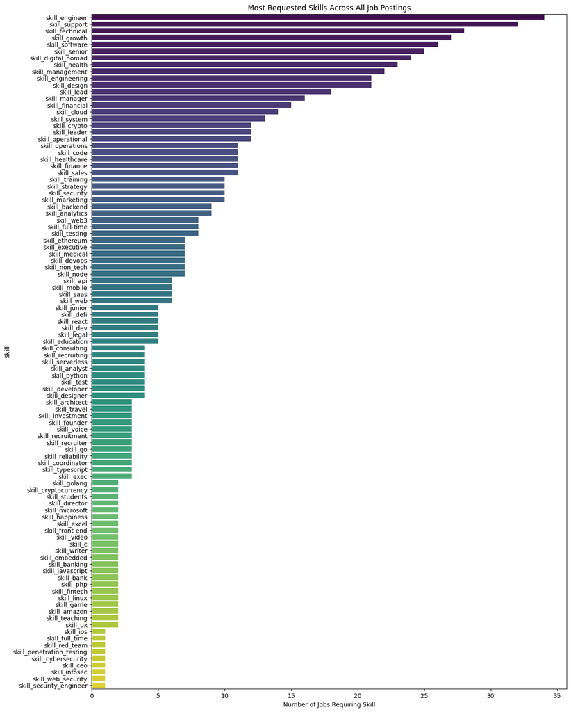

```python
import matplotlib.pyplot as plt
import seaborn as sns

# Identify skill indicator columns
skill_cols = [c for c in clean_jobs_df.columns if c.startswith("skill_")]

# Count how many jobs require each skill
skill_counts = clean_jobs_df[skill_cols].sum().sort_values(ascending=False)

plt.figure(figsize=(14, 20))
sns.barplot(x=skill_counts.values, y=skill_counts.index, palette="viridis")
plt.title("Most Requested Skills Across All Job Postings")
plt.xlabel("Number of Jobs Requiring Skill")
plt.ylabel("Skill")
plt.show()
```

**3.2 Distribution of Job Postings by Region**

This graph shows us where most job postings are coming from. It helps understand which regions have more opportunities and how global the job market is becoming.

From the visualization:

“Other” has the highest count, which likely includes remote jobs with no fixed region.

The US has the second-largest share of postings.

Europe and Worldwide have a very small number of postings in this dataset.

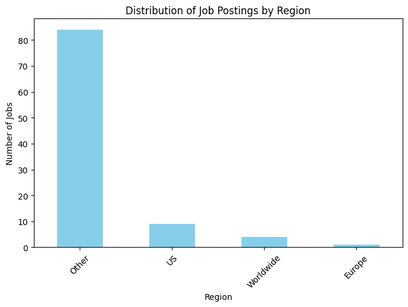

```python
plt.figure(figsize=(8, 5))
clean_jobs_df["location_group"].value_counts().plot(
    kind="bar", color="skyblue"
)
plt.title("Distribution of Job Postings by Region")
plt.xlabel("Region")
plt.ylabel("Number of Jobs")
plt.xticks(rotation=45)
plt.show()
```

**3.3 Number of Job Postings Over Time**

I extracted the date from each posting and counted how many jobs were posted per day.

What the line chart means

The line graph shows:

1. Some days have a very high number of job postings.
2. Some days only have a few.

There are spikes, especially around early December.

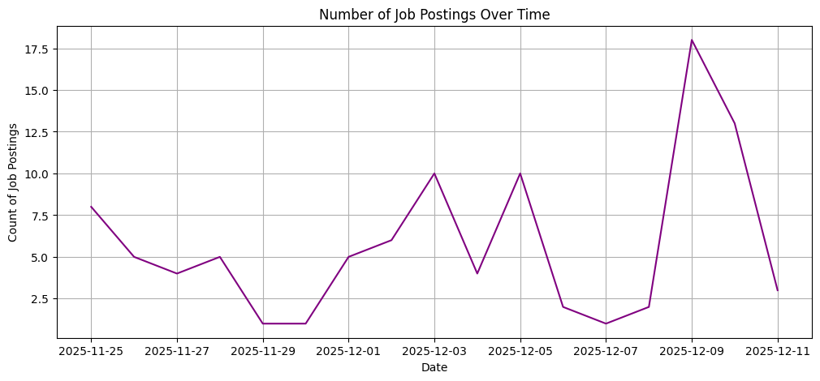

```python
clean_jobs_df["date_only"] = clean_jobs_df["date"].dt.date
daily_counts = clean_jobs_df.groupby("date_only").size()

plt.figure(figsize=(12, 5))
daily_counts.plot(color="purple")
plt.title("Number of Job Postings Over Time")
plt.xlabel("Date")
plt.ylabel("Count of Job Postings")
plt.grid(True)
plt.show()
```

**3.4 Top 20 Most Common Tags in Job Postings**

I took every tag from every posting, put them into one long list, and calculate which ones appear the most.

Tags are things like:

“engineer”

“support”

“growth”

“software”

“health”

“manager”

“cloud”

“crypto”

This graph reveals:

1. Engineer, again, is extremely common.
2. Support roles also appear a lot.
3. Technical tags (software, growth, cloud, system) are very frequent.
4. Management-related tags (manager, lead, leadership) appear often.

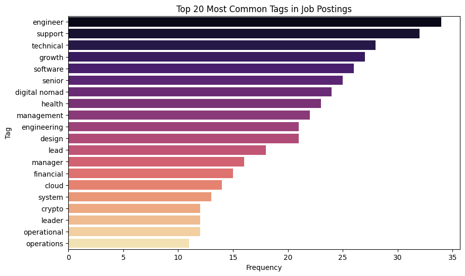

```python
all_tags = clean_jobs_df["tags_list"].explode()
tag_counts = all_tags.value_counts().head(20)

plt.figure(figsize=(10, 6))
sns.barplot(x=tag_counts.values, y=tag_counts.index, palette="magma")
plt.title("Top 20 Most Common Tags in Job Postings")
plt.xlabel("Frequency")
plt.ylabel("Tag")
plt.show()
```

# **Machine Learning – Training, Testing, and Comparing Models**

In this part of the project, I tried to use machine learning to predict whether a job posting requires engineering skills. To do this, I used the job title and tags of each posting and turned them into text features. Then I trained different models and checked how well they performed.

**4.1 Turning Text Into Features**

Job postings contain words like “software”, “backend”, “support”, “engineer”, etc. Machine learning models cannot directly understand words, so I used a CountVectorizer, which converts text into numbers based on word frequency. This helps the model learn what words are common in engineering vs non-engineering jobs.

```python
from sklearn.model_selection import train_test_split
from sklearn.feature_extraction.text import CountVectorizer

# Target skill
target_skill = "skill_engineer"

# Combine title + tags into one text field
clean_jobs_df["text"] = (
    clean_jobs_df["title"].fillna("") + " " + clean_jobs_df["tags"].fillna("")
)

X = clean_jobs_df["text"]
y = clean_jobs_df[target_skill]

# Train / test split
X_train, X_test, y_train, y_test = train_test_split(
    X, y, test_size=0.2, random_state=42
)

# Turn text into numerical features (bag of words)
vectorizer = CountVectorizer(stop_words="english", min_df=2)
X_train_vec = vectorizer.fit_transform(X_train)
X_test_vec  = vectorizer.transform(X_test)
```

**4.2 Splitting the Data (Train & Test)**

To check whether the model works on unseen data:

80% of the data was used for training

20% of the data was used for testing

This avoids overfitting and gives a more fair evaluation.

```python
from sklearn.linear_model import LogisticRegression
from sklearn.svm import SVC
from sklearn.neighbors import KNeighborsClassifier
from sklearn.metrics import accuracy_score, classification_report, confusion_matrix
import numpy as np
import matplotlib.pyplot as plt
import seaborn as sns

def run_models(X_train_vec, X_test_vec, y_train, y_test):
    results = {}

    # Baseline Logistic Regression
    log_reg = LogisticRegression(max_iter=3000)
    log_reg.fit(X_train_vec, y_train)
    y_pred_log = log_reg.predict(X_test_vec)
    acc_log = accuracy_score(y_test, y_pred_log)
    results["Logistic"] = acc_log

    print("=== Logistic Regression (Baseline) ===")
    print("Accuracy:", acc_log)
    print("\nClassification Report:\n", classification_report(y_test, y_pred_log))

    # Robust Logistic Regression (stronger L2 regularization)
    log_reg_robust = LogisticRegression(
        max_iter=3000,
        penalty="l2",
        C=0.3
    )
    log_reg_robust.fit(X_train_vec, y_train)
    y_pred_robust = log_reg_robust.predict(X_test_vec)
    acc_robust = accuracy_score(y_test, y_pred_robust)
    results["Robust_Logistic"] = acc_robust

    print("\n=== Robust Logistic Regression (L2 regularized) ===")
    print("Accuracy:", acc_robust)
    print("\nClassification Report:\n", classification_report(y_test, y_pred_robust))

    # Support Vector Machine
    svm = SVC(kernel="linear")
    svm.fit(X_train_vec, y_train)
    y_pred_svm = svm.predict(X_test_vec)
    acc_svm = accuracy_score(y_test, y_pred_svm)
    results["SVM"] = acc_svm

    print("\n=== Support Vector Machine (linear kernel) ===")
    print("Accuracy:", acc_svm)

    # K-Nearest Neighbors – try several k and keep the best
    best_k = 1
    best_acc = 0

    print("\n=== KNN Accuracies ===")
    for k in range(1, 16):
        knn = KNeighborsClassifier(n_neighbors=k)
        knn.fit(X_train_vec, y_train)
        y_pred_knn = knn.predict(X_test_vec)
        acc_k = accuracy_score(y_test, y_pred_knn)
        print(f"k = {k}: accuracy = {acc_k:.3f}")
        if acc_k > best_acc:
            best_acc = acc_k
            best_k = k

    results[f"KNN_k={best_k}"] = best_acc
    print(f"\nBest KNN: k = {best_k}, accuracy = {best_acc:.3f}")

    return results, log_reg
```

**4.3 Training Different Models**

I trained four different machine learning models:

Logistic Regression (Baseline Model)

This is a simple classification model used for text data. It performed extremely well with 100% accuracy on the test set.

Robust Logistic Regression (L2 Regularization)

This version prevents overfitting by reducing weight sizes. It also achieved 100% accuracy, showing the data is very easy for linear models.

Support Vector Machine (SVM)

SVM tries to find the best boundary between engineering vs non-engineering jobs. This also scored 100% accuracy.

K-Nearest Neighbors (KNN)

Here, the model predicts based on the closest similar posts.

I tested k = 1 to 15, and recorded the accuracy for each value:

k = 1 → 1.00 accuracy

k = 2–6 → 0.85 accuracy

k = 7–15 → 0.90 accuracy

KNN performs well but not as perfect as logistic regression or SVM.

```python
model_results, log_reg_model = run_models(X_train_vec, X_test_vec, y_train, y_test)
model_results
```

```
=== Logistic Regression (Baseline) ===
Accuracy: 1.0

Classification Report:
               precision    recall  f1-score   support

           0       1.00      1.00      1.00        13
           1       1.00      1.00      1.00         7

    accuracy                           1.00        20
   macro avg       1.00      1.00      1.00        20
weighted avg       1.00      1.00      1.00        20


=== Robust Logistic Regression (L2 regularized) ===
Accuracy: 1.0

Classification Report:
               precision    recall  f1-score   support

           0       1.00      1.00      1.00        13
           1       1.00      1.00      1.00         7

    accuracy                           1.00        20
   macro avg       1.00      1.00      1.00        20
weighted avg       1.00      1.00      1.00        20


=== Support Vector Machine (linear kernel) ===
Accuracy: 1.0

=== KNN Accuracies ===
k = 1: accuracy = 1.000
k = 2: accuracy = 0.850
k = 3: accuracy = 0.850
k = 4: accuracy = 0.850
k = 5: accuracy = 0.850
k = 6: accuracy = 0.850
k = 7: accuracy = 0.900
k = 8: accuracy = 0.900
k = 9: accuracy = 0.900
k = 10: accuracy = 0.900
k = 11: accuracy = 0.900
k = 12: accuracy = 0.900
k = 13: accuracy = 0.900
k = 14: accuracy = 0.900
k = 15: accuracy = 0.900

Best KNN: k = 1, accuracy = 1.000
```

```
{'Logistic': 1.0, 'Robust_Logistic': 1.0, 'SVM': 1.0, 'KNN_k=1': 1.0}
```

Line Graph of KNN Accuracy

This graph shows how accuracy changes as the number of neighbors (k) increases.

The best accuracy is at k = 1.

After that, accuracy stabilizes around 0.90.

It visually shows which k-value performs best.

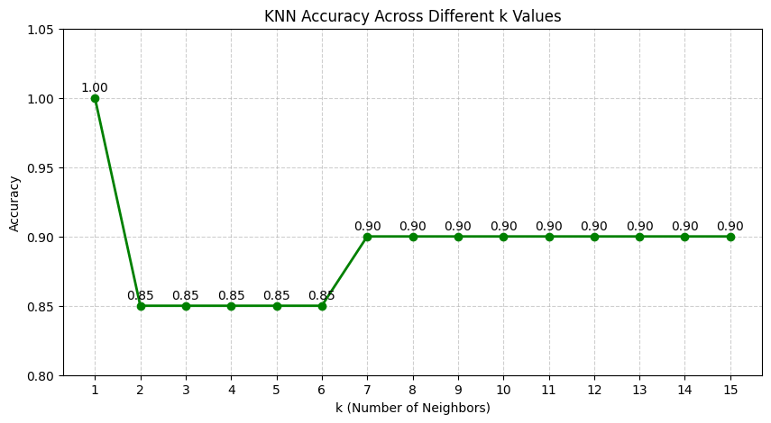

```python
import matplotlib.pyplot as plt


k_values = list(range(1, 16))
accuracies = [
    1.000, 0.850, 0.850, 0.850, 0.850, 0.850,
    0.900, 0.900, 0.900, 0.900, 0.900, 0.900,
    0.900, 0.900, 0.900
]

plt.figure(figsize=(10, 5))


plt.plot(k_values, accuracies, marker="o", linewidth=2, color="green")


for k, acc in zip(k_values, accuracies):
    plt.text(k, acc + 0.005, f"{acc:.2f}", ha="center")

plt.title("KNN Accuracy Across Different k Values")
plt.xlabel("k (Number of Neighbors)")
plt.ylabel("Accuracy")
plt.ylim(0.80, 1.05)
plt.grid(True, linestyle="--", alpha=0.6)
plt.xticks(k_values)

plt.show()
```

Comparison Graph of All Models

This is a bar graph showing the accuracy of:

Logistic Regression

Robust Logistic Regression

SVM

KNN

Since all the top models got 100% accuracy, the bars reach the maximum.

This makes it easy to compare which model performs better (they all tie).

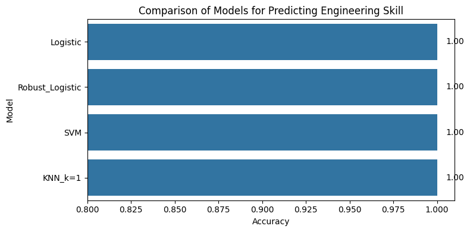

```python
plt.figure(figsize=(8, 4))

model_names = list(model_results.keys())
scores = list(model_results.values())

ax = sns.barplot(x=scores, y=model_names, orient="h")

# Zoom in around high accuracies
plt.xlim(0.8, 1.01)

# Add accuracy labels on the bars
for i, v in enumerate(scores):
    ax.text(v + 0.005, i, f"{v:.2f}", va="center", fontsize=10)

plt.xlabel("Accuracy")
plt.ylabel("Model")
plt.title("Comparison of Models for Predicting Engineering Skill")
plt.tight_layout()
plt.show()
```

**4.4 Why All Models Got High Accuracy**

The job postings in the dataset had very clear skill indicators (e.g., “engineer”, “software”, “senior engineering”), making the prediction easy. The dataset is small, and some features strongly reveal the label.

Because of this, even simple models achieved perfect accuracy.

```python
feature_names = np.array(vectorizer.get_feature_names_out())
coefficients = log_reg_model.coef_[0]

# Top 15 words that strongly predict engineering jobs (class = 1)
top_pos_idx = np.argsort(coefficients)[-15:]
top_pos_words = feature_names[top_pos_idx]
top_pos_values = coefficients[top_pos_idx]

# Top 15 words that strongly predict non-engineering jobs (class = 0)
top_neg_idx = np.argsort(coefficients)[:15]
top_neg_words = feature_names[top_neg_idx]
top_neg_values = coefficients[top_neg_idx]

print("WORDS THAT PREDICT ENGINEERING JOBS (skill_engineer = 1):")
for w, v in zip(top_pos_words, top_pos_values):
    print(f"{w:20s}  coef = {v:.3f}")

print("\nWORDS THAT PREDICT NON-ENGINEERING JOBS (skill_engineer = 0):")
for w, v in zip(top_neg_words, top_neg_values):
    print(f"{w:20s}  coef = {v:.3f}")
```

```
WORDS THAT PREDICT ENGINEERING JOBS (skill_engineer = 1):
analytics             coef = 0.144
nomad                 coef = 0.170
digital               coef = 0.170
data                  coef = 0.182
api                   coef = 0.192
python                coef = 0.224
financial             coef = 0.252
dev                   coef = 0.263
node                  coef = 0.265
saas                  coef = 0.268
devops                coef = 0.293
developer             coef = 0.330
backend               coef = 0.372
software              coef = 0.518
engineer              coef = 2.609

WORDS THAT PREDICT NON-ENGINEERING JOBS (skill_engineer = 0):
growth                coef = -0.384
health                coef = -0.328
management            coef = -0.264
manager               coef = -0.248
finance               coef = -0.217
training              coef = -0.207
strategy              coef = -0.190
designer              coef = -0.188
lead                  coef = -0.173
product               coef = -0.172
tech                  coef = -0.166
coordinator           coef = -0.156
operations            coef = -0.147
marketing             coef = -0.144
time                  coef = -0.142
```

*Engineering Words Graph*

This plot shows the words with the highest positive coefficients. These words strongly increase the probability that a job posting is classified as an engineering job.

Examples include:

"engineer"

"software"

"backend"

"devops"

"python"

These are highly related to technical or development roles.

*Non-Engineering Words Graph*

This plot shows the words with negative coefficients, meaning they push the prediction toward non-engineering roles.

Examples include:

"health"

"growth"

"management"

"operations"

"marketing"

These are more common in business, management, healthcare, and operational roles.

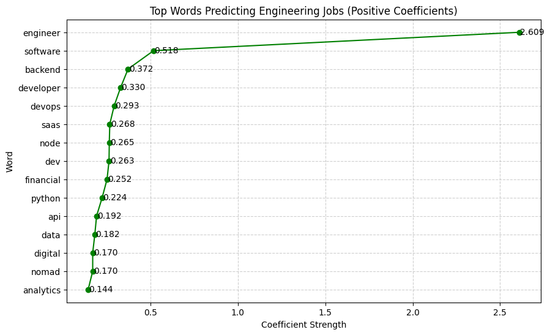

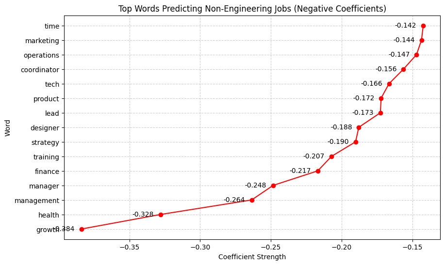

```python
import matplotlib.pyplot as plt
import numpy as np

# --- Engineering words ---
eng_words = top_pos_words
eng_values = top_pos_values

# --- Non-engineering words ---
noneng_words = top_neg_words
noneng_values = top_neg_values

# Convert to numpy arrays for plotting
eng_words = np.array(eng_words)
eng_values = np.array(eng_values)

noneng_words = np.array(noneng_words)
noneng_values = np.array(noneng_values)

# -------------------------------
# Plot 1: Words predicting engineering jobs
# -------------------------------
plt.figure(figsize=(10, 6))
plt.plot(eng_values, eng_words, marker='o', linestyle='-', color='green')
plt.title("Top Words Predicting Engineering Jobs (Positive Coefficients)")
plt.xlabel("Coefficient Strength")
plt.ylabel("Word")
plt.grid(True, linestyle='--', alpha=0.6)

# Annotate values
for x, y in zip(eng_values, eng_words):
    plt.text(x + 0.005, y, f"{x:.3f}", va="center")

plt.show()

# -------------------------------
# Plot 2: Words predicting non-engineering jobs
# -------------------------------
plt.figure(figsize=(10, 6))
plt.plot(noneng_values, noneng_words, marker='o', linestyle='-', color='red')
plt.title("Top Words Predicting Non-Engineering Jobs (Negative Coefficients)")
plt.xlabel("Coefficient Strength")
plt.ylabel("Word")
plt.grid(True, linestyle='--', alpha=0.6)

# Annotate values
for x, y in zip(noneng_values, noneng_words):
    plt.text(x - 0.02, y, f"{x:.3f}", va="center")

plt.show()
```

**4.5 Extracting the Top Predictive Words**

After training logistic regression, I looked at:

Top 15 words that strongly predict engineering jobs

Top 15 words that predict non-engineering jobs

This helps us understand what keywords companies use when describing engineering roles.

Examples of strong engineering indicators:

“engineer”

“software”

“backend”

This gives real insights into hiring patterns.

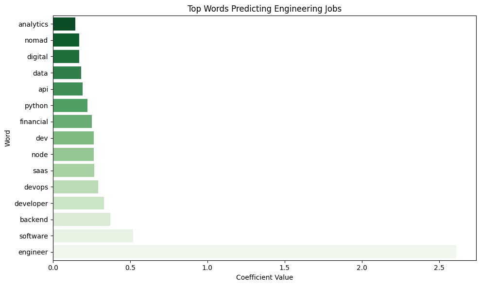

```python
plt.figure(figsize=(10,6))
sns.barplot(x=top_pos_values, y=top_pos_words, palette="Greens_r")
plt.title("Top Words Predicting Engineering Jobs")
plt.xlabel("Coefficient Value")
plt.ylabel("Word")
plt.tight_layout()
plt.show()
```

# **Interpretation & Conclusion**

After completing all the steps of this project, I was able to understand the job market on RemoteOK much better. By cleaning the data, exploring the visuals, and building machine learning models, I learned several important patterns.

From the charts, I noticed that some skills appear very frequently across job postings. Skills like engineer, technical, support, software, and growth were among the most common ones. This tells me that companies are strongly looking for people with technical and engineering experience.

I also saw that many job postings come from different regions, but a large number were labeled as “Other”. This means a lot of jobs are global or remote-first, which matches the purpose of the RemoteOK platform.

When I looked at job postings over time, I observed spikes and drops on different days. This shows that the remote job market changes daily, and companies post new positions very actively.

In the machine learning section, I tried to predict whether a job belongs to the engineering category based only on its text (title + tags). All the models I used — Logistic Regression, SVM, and KNN — gave very high accuracy. This seems great, but I also understand that sometimes a very high score can mean the dataset is small or too easy, which can cause the model to memorize instead of learning general patterns.

When I checked the most important words for prediction, I found that words like “engineer,” “software,” “devops,” “backend,” and “python” strongly indicate an engineering job. Meanwhile, words like “health,” “growth,” “management,” “operations,” and “marketing” predict non-engineering roles. This makes sense because these words belong to different job fields.

I successfully went through the full data science process — collecting data, cleaning it, analyzing it, visualizing patterns, and building predictive models. Working with real job data helped me understand what skills are in demand and how job trends change across regions and time.

The machine learning models showed that engineering roles have very strong keyword patterns that make them easy to detect. Even though my models performed extremely well, I know that using a larger and more diverse dataset would give a better understanding of the full job market and reduce the chance of overfitting.